# Scraping Twitter Data – Example

Asmik & Lisa – for Intro to NLP

30 April 2021

```r
# Load required packages

library("rtweet")
library("stringr")
library("tidytext")
library("tidyverse")
```

### Set up API access

We need to set up our API token prior to executing the following code, which we did in the background here so as to not make our credentials public. Note that you need to define your personal `consumer_key`, `consumer_secret`, `access_token`, and `access_secret` accordingly.

```r
personal_token <- rtweet::create_token(
  consumer_key = consumer_key,
  consumer_secret = consumer_secret,
  access_token = access_token,
  access_secret = access_secret)
```

### Extract relevant tweets

We search for tweets with hashtag *#merkel*. `rtweet` conveniently returns a `data.frame` object to which we add a `query` column:

```r
scraped_tweets_merkel <- rtweet::search_tweets(
  "#merkel", # i.e.: match exact phrase, # for hashtag, @ for mentions)
  n = 1000, # cap to 1k hits (max: 18k)
  lang = "de", # set account language
  include_rts = FALSE, # exclude retweets
  type = "recent", # alternatively, "popular" or "mixed"
  token = personal_token)

scraped_tweets_merkel$query <- "Merkel"
```

Now, search for tweets with hashtag *AfD*:

```r
scraped_tweets_afd <- rtweet::search_tweets(
  "#AfD",
  n = 1000,
  lang = "de",
  include_rts = FALSE,
  type = "recent",
  token = personal_token)

scraped_tweets_afd$query <- "AfD"
```

Combine both:

```r
combined_tweets <- dplyr::bind_rows(scraped_tweets_merkel, scraped_tweets_afd)

head(combined_tweets)
```

```
## # A tibble: 6 x 91
##   user_id status_id created_at          screen_name text  source
##   <chr>   <chr>     <dttm>              <chr>       <chr> <chr>
## 1 132847~ 13800702~ 2021-04-08 08:09:14 KastCaro    "@we~ Twitt~
## 2 132847~ 13798139~ 2021-04-07 15:10:49 KastCaro    "@we~ Twitt~
## 3 132847~ 13800311~ 2021-04-08 05:34:04 KastCaro    "@ZD~ Twitt~
## 4 132847~ 13800486~ 2021-04-08 06:43:43 KastCaro    "@BI~ Twitt~
## 5 132847~ 13800653~ 2021-04-08 07:49:59 KastCaro    "@ZD~ Twitt~
## 6 132847~ 13798658~ 2021-04-07 18:37:01 KastCaro    "@fa~ Twitt~
## # ... with 85 more variables: display_text_width <dbl>,
## #   reply_to_status_id <chr>, reply_to_user_id <chr>,
## #   reply_to_screen_name <chr>, is_quote <lgl>, is_retweet <lgl>,
## #   favorite_count <int>, retweet_count <int>, quote_count <int>,
## #   reply_count <int>, hashtags <list>, symbols <list>, urls_url <list>,
## #   urls_t.co <list>, urls_expanded_url <list>, media_url <list>,
## #   media_t.co <list>, media_expanded_url <list>, media_type <list>,
## #   ext_media_url <list>, ext_media_t.co <list>, ext_media_expanded_url <list>,
## #   ext_media_type <chr>, mentions_user_id <list>, mentions_screen_name <list>,
## #   lang <chr>, quoted_status_id <chr>, quoted_text <chr>,
## #   quoted_created_at <dttm>, quoted_source <chr>, quoted_favorite_count <int>,
## #   quoted_retweet_count <int>, quoted_user_id <chr>, quoted_screen_name <chr>,
## #   quoted_name <chr>, quoted_followers_count <int>,
## #   quoted_friends_count <int>, quoted_statuses_count <int>,
## #   quoted_location <chr>, quoted_description <chr>, quoted_verified <lgl>,
## #   retweet_status_id <chr>, retweet_text <chr>, retweet_created_at <dttm>,
## #   retweet_source <chr>, retweet_favorite_count <int>,
## #   retweet_retweet_count <int>, retweet_user_id <chr>,
## #   retweet_screen_name <chr>, retweet_name <chr>,
## #   retweet_followers_count <int>, retweet_friends_count <int>,
## #   retweet_statuses_count <int>, retweet_location <chr>,
## #   retweet_description <chr>, retweet_verified <lgl>, place_url <chr>,
## #   place_name <chr>, place_full_name <chr>, place_type <chr>, country <chr>,
## #   country_code <chr>, geo_coords <list>, coords_coords <list>,
## #   bbox_coords <list>, status_url <chr>, name <chr>, location <chr>,
## #   description <chr>, url <chr>, protected <lgl>, followers_count <int>,
## #   friends_count <int>, listed_count <int>, statuses_count <int>,
## #   favourites_count <int>, account_created_at <dttm>, verified <lgl>,
## #   profile_url <chr>, profile_expanded_url <chr>, account_lang <lgl>,
## #   profile_banner_url <chr>, profile_background_url <chr>,
## #   profile_image_url <chr>, query <chr>
```

We can also conduct multiple independent search queries. The following examples gives us a `list`, each of whose entries is a `data.frame` as in the previous examples. In order to coerce the entries to a single `data.frame`, we call `rbind` on the `list` elements afterwards:

```r
# Combine multiple search queries

tweets_multiple <- lapply(
  c("#afd", "#corona OR #merkel"),
  function(i) {rtweet::search_tweets(
    q = i,
    n = 100,
    lang = "de",
    token = personal_token)})

# Use rtweet's wrapper around do.call(rbind, ...)

tweets_multiple_df <- rtweet::do_call_rbind(tweets_multiple)

head(tweets_multiple_df)
```

```
## # A tibble: 6 x 90
##   user_id status_id created_at          screen_name text  source
##   <chr>   <chr>     <dttm>              <chr>       <chr> <chr>
## 1 111225~ 13800702~ 2021-04-08 08:09:18 KKadro      "Vor~ Twitt~
## 2 217979~ 13800701~ 2021-04-08 08:09:10 Ohrgeraeus~ "Jed~ Twitt~
## 3 131243~ 13800701~ 2021-04-08 08:09:08 Tzerberus1  "Vor~ Twitt~
## 4 124021~ 13800701~ 2021-04-08 08:09:08 Cigdem8451~ "Mit~ Twitt~
## 5 298771~ 13800701~ 2021-04-08 08:08:50 daswarkein~ "Vor~ Twitt~
## 6 115575~ 13800700~ 2021-04-08 08:08:28 rabenfeder~ "Die~ Twitt~
## # ... with 84 more variables: display_text_width <dbl>,
## #   reply_to_status_id <chr>, reply_to_user_id <chr>,
## #   reply_to_screen_name <chr>, is_quote <lgl>, is_retweet <lgl>,
## #   favorite_count <int>, retweet_count <int>, quote_count <int>,
## #   reply_count <int>, hashtags <list>, symbols <list>, urls_url <list>,
## #   urls_t.co <list>, urls_expanded_url <list>, media_url <list>,
## #   media_t.co <list>, media_expanded_url <list>, media_type <list>,
## #   ext_media_url <list>, ext_media_t.co <list>, ext_media_expanded_url <list>,
## #   ext_media_type <chr>, mentions_user_id <list>, mentions_screen_name <list>,
## #   lang <chr>, quoted_status_id <chr>, quoted_text <chr>,
## #   quoted_created_at <dttm>, quoted_source <chr>, quoted_favorite_count <int>,
## #   quoted_retweet_count <int>, quoted_user_id <chr>, quoted_screen_name <chr>,
## #   quoted_name <chr>, quoted_followers_count <int>,
## #   quoted_friends_count <int>, quoted_statuses_count <int>,
## #   quoted_location <chr>, quoted_description <chr>, quoted_verified <lgl>,
## #   retweet_status_id <chr>, retweet_text <chr>, retweet_created_at <dttm>,
## #   retweet_source <chr>, retweet_favorite_count <int>,
## #   retweet_retweet_count <int>, retweet_user_id <chr>,
## #   retweet_screen_name <chr>, retweet_name <chr>,
## #   retweet_followers_count <int>, retweet_friends_count <int>,
## #   retweet_statuses_count <int>, retweet_location <chr>,
## #   retweet_description <chr>, retweet_verified <lgl>, place_url <chr>,
## #   place_name <chr>, place_full_name <chr>, place_type <chr>, country <chr>,
## #   country_code <chr>, geo_coords <list>, coords_coords <list>,
## #   bbox_coords <list>, status_url <chr>, name <chr>, location <chr>,
## #   description <chr>, url <chr>, protected <lgl>, followers_count <int>,
## #   friends_count <int>, listed_count <int>, statuses_count <int>,
## #   favourites_count <int>, account_created_at <dttm>, verified <lgl>,
## #   profile_url <chr>, profile_expanded_url <chr>, account_lang <lgl>,
## #   profile_banner_url <chr>, profile_background_url <chr>,
## #   profile_image_url <chr>
```

We can also search for users:

```r
scraped_tweets_lauterbach <- rtweet::get_timeline (
  "Karl_Lauterbach",
  n = 100,
  lang = "de",
  include_rts = FALSE,
  type = "popular",
  token = personal_token)

head(scraped_tweets_lauterbach)
```

```
## # A tibble: 6 x 90
##   user_id status_id created_at          screen_name text  source
##   <chr>   <chr>     <dttm>              <chr>       <chr> <chr>
## 1 329298~ 13798845~ 2021-04-07 19:51:39 Karl_Laute~ Dies~ Twitt~
## 2 329298~ 13798741~ 2021-04-07 19:10:16 Karl_Laute~ Den ~ Twitt~
## 3 329298~ 13798568~ 2021-04-07 18:01:29 Karl_Laute~ Astr~ Twitt~
## 4 329298~ 13798114~ 2021-04-07 15:01:08 Karl_Laute~ (5) ~ Twitt~
## 5 329298~ 13798114~ 2021-04-07 15:01:08 Karl_Laute~ (4) ~ Twitt~
## 6 329298~ 13798114~ 2021-04-07 15:01:08 Karl_Laute~ (3) ~ Twitt~
## # ... with 84 more variables: display_text_width <dbl>,
## #   reply_to_status_id <chr>, reply_to_user_id <chr>,
## #   reply_to_screen_name <chr>, is_quote <lgl>, is_retweet <lgl>,
## #   favorite_count <int>, retweet_count <int>, quote_count <int>,
## #   reply_count <int>, hashtags <list>, symbols <list>, urls_url <list>,
## #   urls_t.co <list>, urls_expanded_url <list>, media_url <list>,
## #   media_t.co <list>, media_expanded_url <list>, media_type <list>,
## #   ext_media_url <list>, ext_media_t.co <list>, ext_media_expanded_url <list>,
## #   ext_media_type <chr>, mentions_user_id <list>, mentions_screen_name <list>,
## #   lang <chr>, quoted_status_id <chr>, quoted_text <chr>,
## #   quoted_created_at <dttm>, quoted_source <chr>, quoted_favorite_count <int>,
## #   quoted_retweet_count <int>, quoted_user_id <chr>, quoted_screen_name <chr>,
## #   quoted_name <chr>, quoted_followers_count <int>,
## #   quoted_friends_count <int>, quoted_statuses_count <int>,
## #   quoted_location <chr>, quoted_description <chr>, quoted_verified <lgl>,
## #   retweet_status_id <chr>, retweet_text <chr>, retweet_created_at <dttm>,
## #   retweet_source <chr>, retweet_favorite_count <int>,
## #   retweet_retweet_count <int>, retweet_user_id <chr>,
## #   retweet_screen_name <chr>, retweet_name <chr>,
## #   retweet_followers_count <int>, retweet_friends_count <int>,
## #   retweet_statuses_count <int>, retweet_location <chr>,
## #   retweet_description <chr>, retweet_verified <lgl>, place_url <chr>,
## #   place_name <chr>, place_full_name <chr>, place_type <chr>, country <chr>,
## #   country_code <chr>, geo_coords <list>, coords_coords <list>,
## #   bbox_coords <list>, status_url <chr>, name <chr>, location <chr>,
## #   description <chr>, url <chr>, protected <lgl>, followers_count <int>,
## #   friends_count <int>, listed_count <int>, statuses_count <int>,
## #   favourites_count <int>, account_created_at <dttm>, verified <lgl>,
## #   profile_url <chr>, profile_expanded_url <chr>, account_lang <lgl>,
## #   profile_banner_url <chr>, profile_background_url <chr>,
## #   profile_image_url <chr>
```

`rtweet` provides some other useful functionalities. For instance, analyzing tweets might require extraction of emojis:

```r
head(rtweet::emojis)
```

```
## # A tibble: 6 x 2
##   code         description
##   <chr>        <chr>
## 1 "\U0001f600" grinning face
## 2 "\U0001f601" beaming face with smiling eyes
## 3 "\U0001f602" face with tears of joy
## 4 "\U0001f923" rolling on the floor laughing
## 5 "\U0001f603" grinning face with big eyes
## 6 "\U0001f604" grinning face with smiling eyes
```

### Explore scraped data

Tweets’ timeline – frequency of tweets over time:

```r
summary(combined_tweets$created_at)
```

```
##                  Min.               1st Qu.                Median
## "2021-04-05 14:28:15" "2021-04-06 21:36:00" "2021-04-07 13:44:36"
##                  Mean               3rd Qu.                  Max.
## "2021-04-07 09:35:19" "2021-04-07 19:40:43" "2021-04-08 08:09:14"
```

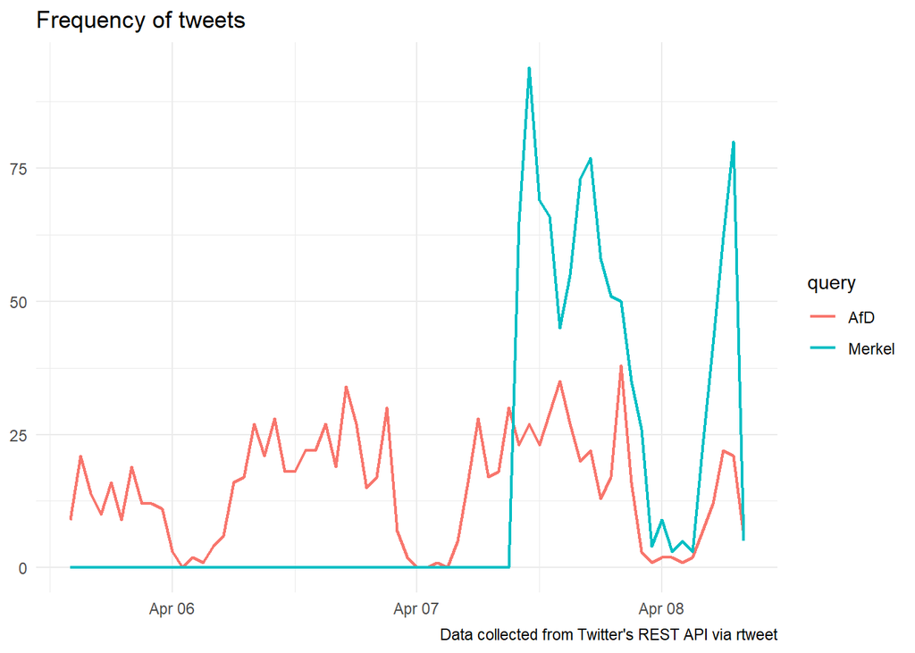

```r
combined_tweets %>%
  dplyr::group_by(query) %>%
  rtweet::ts_plot("hours", cex = 0.8) +
  labs(
    x = NULL,
    y = NULL,
    title = "Frequency of tweets",
       # subtitle = paste0(format(min(combined_tweets$created_at), "%d %B %Y"), " to ", format(max(combined_tweets$created_at),"%d %B %Y")),
    caption = "Data collected from Twitter's REST API via rtweet") +
  theme_minimal()
```

Most retweeted tweet:

```r
most_retweeted_tweet <- combined_tweets %>%
  dplyr::arrange(-retweet_count) %>%
  dplyr::slice(1) %>%
  dplyr::select(created_at, screen_name, text, retweet_count, status_id)

print(most_retweeted_tweet$text)
```

```
## [1] "Die Sachsen machen’s vor! In #Sachsen ist die #AfD mittlerweile stärkste Partei! #SPD und #Linke schmieren zu Recht ab. #Grüne demnächst auch. https://t.co/d6YBjnifhB"
```

Top hashtags:

```r
combined_tweets %>%
  tidytext::unnest_tokens(hashtag, text, "tweets", to_lower = FALSE) %>%
  dplyr::filter(
    stringr::str_detect(hashtag, "^#")) %>%
  dplyr::count(hashtag) %>%
  dplyr::slice_max(n, n = 5)
```

```
## # A tibble: 6 x 2
##   hashtag       n
##   <chr>     <int>
## 1 #Merkel     907
## 2 #AfD        797
## 3 #CDU        174
## 4 #Corona     112
## 5 #Lockdown    99
## 6 #NoAfD       99
```

**The limitations on time period and number of tweets might be prohibitive, depending on the goal of the analysis, but otherwise, `rtweet` is quite powerful and convenient to handle.**